# Mathematics 241 - Case Studies in Statistical Analysis (Spring 2017)

##### Taught by Andrew Bray and Paul Gronke

This repository contains my work from a data sceicne course that I am currently enrolled in. Each homework excercise showcases my ability to perform crucial steps in a data science project:

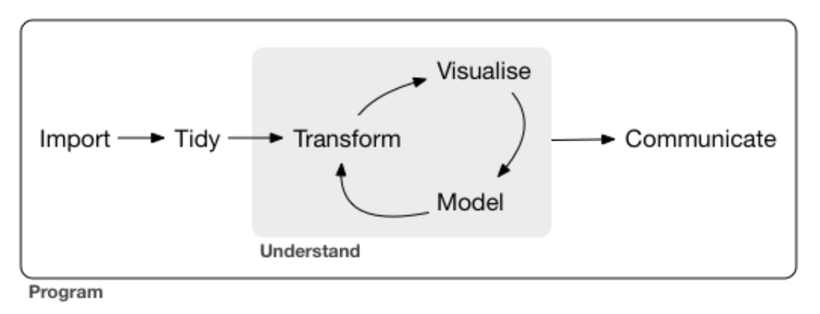

Picture from r4ds.had.co.nz

In this repository, you will find folders containing the following excercises and projects:

hw_0_data_viz: Explore voting participation trends within Oregon voters via visualization with ggplot2.

hw_1_wrangle: Explore implications of the newly implemented motor voter registration system on voting trends in Oregon.

hw_2_review: Excercises from http://mdsr-book.github.io

hw_3_tidy: Excercises from http://mdsr-book.github.io

hw_4_import: Gain experience with Data Import through by importing and tidying 3 novel data sets.

hw_5_logit: Apply four models to answer the question of the association between age and whether or not a registered voter in Oregon voted in the 2016 election.

us_elections (work in progress): Improve data visualizations for the US Elections Project (http://www.electproject.org). Create templates of fully automated and reproducible interactive maps via shiny.